# Transcriptomics Tutorial - Days 1 and 2: Intro to the copepod study system, dataset, and working on command line

Melissa H. Pespeni

Fall 2026

# Learning Objectives for today:

#### *By the end of this class, you will be able to…*

1. Understand the experimental design and data and questions that can be addressed with these data.
2. Understand what a `.fastq` file is.
3. Understand the work flow or “pipeline” for processing and analyzing RNAseq data.
4. Conceptualize a “counts” file.

#### Activities to achieve these objectives:

1. Interactive introduction to transcriptomics and RNAseq data analysis.
2. Introduction of the study system and experiment.
3. Generate questions that can be addresses with these data.
4. Look at a raw sequence data file!
5. Work in R to import, assess, and visualize the data.

## 1. What are the molecular underpinnings of survival in global change conditions?

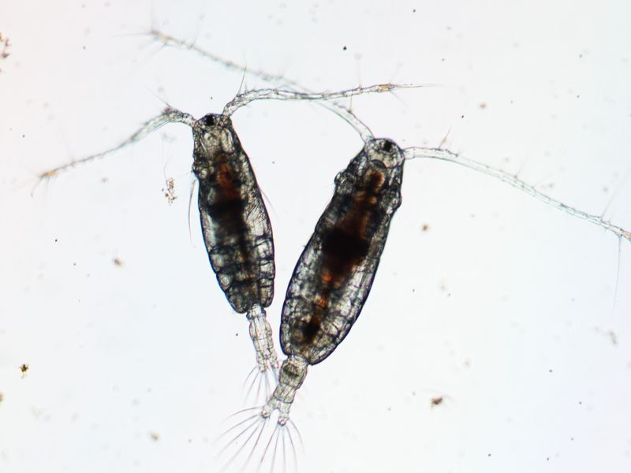

https://www.diark.org/diark/species_list/Acartia_tonsa

Copepods are one of the most abundant animals on planet. Calenoid copepods, particularly in the genus Acartia, are critical for ecosystem functioning and biogeochemical cycling. They are primary consumers at the base of the oceanic food chain, eating phytoplankton and transferring the energy up the food chain starting with larval fish. With the rapidly rising temperatures in the ocean, it is critical to understand how such ecologically important species will tolerate these changes.

*Acartia tonsa* is a globally distributed estuarine and near-shore coastal species found along east Coast of the US. In a number of studies described below, we’ve found that *A. tonsa* has the capacity to rapidly adapt to global change conditions using both genetic and epigenetic variation, i.e., using both genetic and plastic mechanisms. However, what about their cold-adapted sister species, *Acartia hudsonica*?! *A. hudsonica* is a “cold-adapted” estuarine and near-shore coastal species. It is most abundant along the New England coast (ME, NH, MA, RI, CT), generally not further south than the Chesapeake Bay and not further north than Laborador/Newfoundland, Canada. They are particularly interesting because they experience huge swings in temperature across the seasons, thus they may have high plasticity, i.e., physiological flexibility. However, they typically experience much lower temperatures on average, thus their tolerance for elevated temperatures is lower than their sister species, *A. tonsa*.

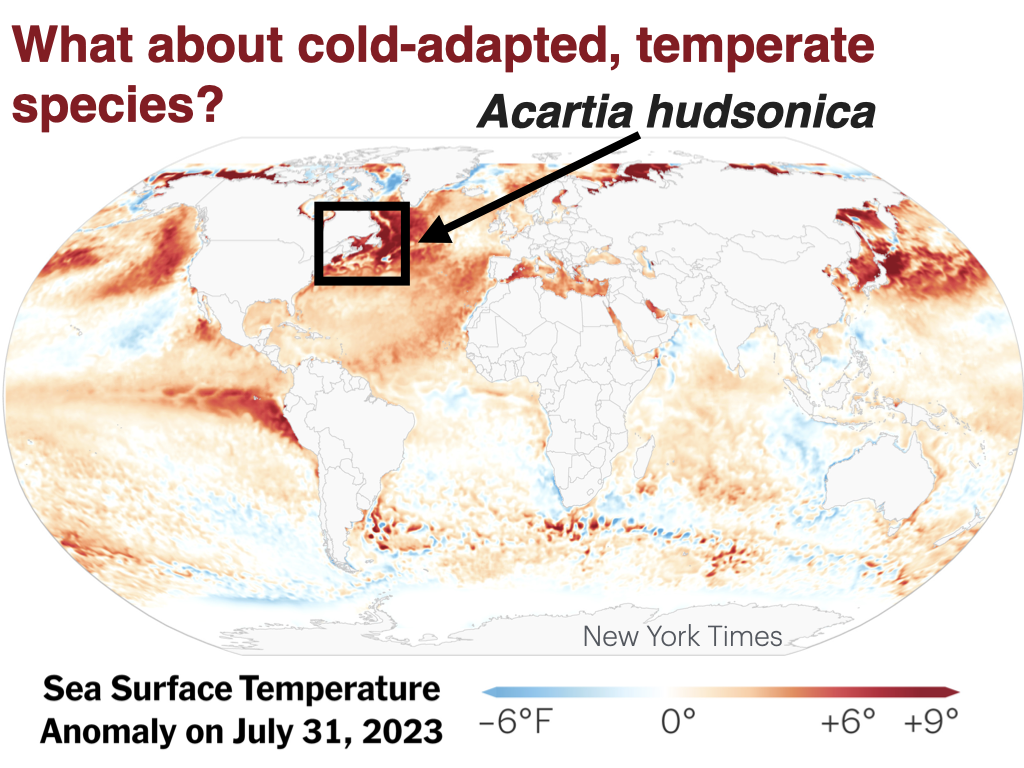

In addition, there are two other major gaps in knowledge: we have never measured the initial plastic and long-term evolved responses in a single experiment. Nor have we measured gene expression responses to multiple environmental stressors.

In a collaboration with colleagues at the University of Connecticutt and with funding from the National Science Foundation (2016-2019), we have carried out long-term experimental evolution studies in high temperature and low pH in these two Acartiid species to understand their capacity for and mechanisms of resilience. We have measured phenotypic, allelic, epi-allelic, and transcriptomic responses across the generations in full factorial and reciprocal transplant experiments. Below is a summary of what we have learned thus far.

- *A. tonsa* can rapidly adapt to high to high temperature, low pH, and the combination, but with long-term costs revealed after 25 generations ([Dam *et al.* 2021 *Nature Climate Change*](https://www.nature.com/articles/s41558-021-01131-5)).
- Looking at the allelic responses to selection in *A. tonsa*, warming was the dominant driver of evolution in the combined warming and acidification treatment. However, the combination was highly synergistic with 47% of the selection response being unique from either treatment alone ([Brennan *et al.* 2022 *PNAS*](https://www.pnas.org/doi/abs/10.1073/pnas.2201521119)). These results highlight the challenge that concurrent stressors impose on predictions of adaptation to complex environmental changes.
- In a reciprocal transplant study in *A. tonsa*, we found that transcriptional plasticity was lost after 15 generations of experimental evolution in global change conditions, but there was sustained genetic capacity to re-adapt to ancestral ambient conditions at the expense of genetic diversity ([Brennan *et al.* 2022 *Nature Communications*](https://www.nature.com/articles/s41467-022-28742-6)).
- *A. hudsonica* can also rapidly adapt to high temperature, low pH, and the combination, but with reduced survival revealed after 11 generations (~ one year) ([deMayo *et al.* 2023 *Proc. Roy. Soc. B*](https://royalsocietypublishing.org/doi/abs/10.1098/rspb.2023.1033)).
- We recently showed that both epigenetic and genetic changes seem to play a role in adaptation to global change conditions in these copepods across 25 generations ([Brennan et al. 2025 PNAS](https://www.pnas.org/doi/10.1073/pnas.2422782122); read press release [here](https://www.uvm.edu/uvmnews/news/molecular-hope-tiny-ocean-creatures-reveal-dual-paths-climate-resilience)).
- We’ve also shown that these copepods can achieve a boost in their thermal tolerance in just one generation – as beneficial as three or >40 generations ([Ashlock et al. 2024 Ecology & Evolution](https://onlinelibrary.wiley.com/doi/full/10.1002/ece3.10995)).

## Unpublished RNAseq data from an amazing *A. hudsonica* experiment

We measured gene expression of the experimentally evolved *A. hudsonica* across 12 generations in four sets of conditions:

1. Ambient (AM; 13 degrees C, 400 micro-atm pCO2)
2. Ocean Warming (OW; 15 degrees C, 400 micro-atm pCO2)
3. Ocean Acidification (OA; 13 degrees C, 1000 micro-atm pCO2)
4. Ocean Warming and Acidification (OWA; 15 degrees C; 1000 micro-atm pCO2)

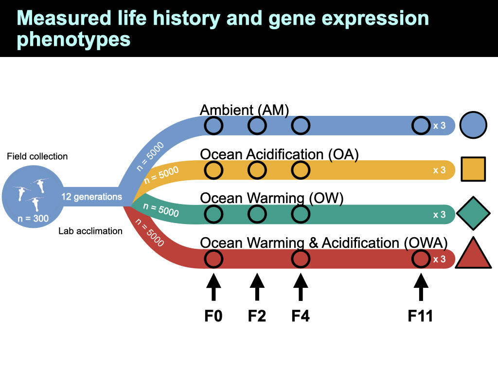

### Realized sample replication after sequencing: N=38 x 2 = 76 (left and right reads)

| Trt | Generation | Nreps |
| --- | --- | --- |
| Ambient (AA) | F0 | 3 |
| Ambient (AA) | F2 | 2 |
| Ambient (AA) | F4 | 3 |
| Ambient (AA) | F11 | 3 |
| Acidification (AH) | F0 | 3 |
| Acidification (AH) | F2 | 3 |
| Acidification (AH) | F4 | 3 |
| Warming (HA) | F0 | 3 |
| Warming (HA) | F2 | 3 |
| Warming (HA) | F4 | 3 |
| Acidification+Warming (HH) | F0 | 3 |
| Acidification+Warming (HH) | F4 | 3 |
| Acidification+Warming (HH) | F11 | 3 |
| ———– | ————- | ——- |
| Total |  | 38 |

## 3. The general workflow for analyzing gene expression data (Transcriptomics pipeline):

### Clean the raw sequence data (Done!)

- [FastP](https://github.com/OpenGene/fastp) on raw reads –> cleaned reads

### Generate and annotate a de novo reference transcriptome assembly (Done!)

- Used [Trinity](https://github.com/trinityrnaseq/trinityrnaseq/wiki)
- Evaluated transcriptome assembly for quality (length and completeness) using [BUSCO](https://busco.ezlab.org/).

### Map the clean reads to the reference assembly (Done!)

- Use [Salmon](https://salmon.readthedocs.io/en/latest/salmon.html) to simulateously map reads to reference transcriptome and quantify abundance.

### Test for differential expression among groups (Here’s where we start!)

- [Import](https://bioconductor.org/packages/release/bioc/vignettes/tximport/inst/doc/tximport.html#3%E2%80%99_tagged_rna-seq) the data into [DESeq2](http://bioconductor.org/packages/devel/bioc/vignettes/DESeq2/inst/doc/DESeq2.html) in R for data normalization, visualization, and statistical tests for differential gene expression.

### Perform more advanced analyses (This is us!)

- Identify clusters of genes with correlated expression using Weighted Gene Correlation Network Analysis ([WGCNA](https://horvath.genetics.ucla.edu/html/CoexpressionNetwork/Rpackages/WGCNA/)).
- Test for functional enrichment among genes differentially expressed between groups using [TopGO](https://bioconductor.org/packages/release/bioc/html/topGO.html) or GO Mann-Whitney U GO_MWU

## 4. What does raw Illumina sequence data look like?!

### fastq

The sequence data files have the suffix `.fastq` (or `.fq`). With paired end sequencing there are two files per sample (left and right reads, `_1.fq.gz`, `_2.fq.gz`). Each file has a series of four lines for each read that includes:

1. Sequence identifier (read name)
2. Nucleotide sequence (A, T, G, C, and sometimes N)
3. Separator line (usually just +)
4. Quality scores for each base

For example:

```
@LH00891:141:235L3LLT3:7:1101:13675:1048 1:N:0:CGTACTAG+AGGCTTAG
ANCCATGCATGTGCCAAGTTAGAGAGACTACGAGAGGCTCATTAAAACATATCAACTTGATCGAATAG
+
I#IIIIIIIIIIIIIIIIIIIIIIIIIIIIIIIIIIIIIIIIIIIIIIIIIIIIIIIIIIIIIIIIII
```

```
 Quality encoding: !"#$%&'()*+,-./0123456789:;<=>?@ABCDEFGHI
                   |         |         |         |         |
    Quality score: 0........10........20........30........40
```

If P is the probability that a base call is an error, then: Q = -10*log10(P)

So:

| Phred Quality Score | Probability of incorrect base call | Base call accuracy |
| --- | --- | --- |
| 10 | 1 in 10 | 90% |
| 20 | 1 in 100 | 99% |
| 30 | 1 in 1000 | 99.9% |
| 40 | 1 in 10,000 | 99.99% |

### Let’s take a look at some real files!

1. Open up VACC OpenOnDemand and initiate an RStudio session and a terminal window (or use Terminal from within R).
2. Let’s learn some unix commands. Navigate to `/gpfs1/cl/ecogen/Transcriptomics/CleanData` using `cd` and `ll`. How can you tell if an object is a file or a directory/folder?
3. Let’s take a peek into one of the gzipped fastq files using `zcat` but make sure to *“pipe”* `|` it to the program `head` and give `head` the parameter of how many lines to print with the *“flag”* `-n 4`. Make it a multiple of 4 so that you’re seeing all four lines of one *“read”*.
4. How would you count how many reads are in a file? We could use `zcat` and pipe to the little program `wc` for “word count” and give it the flag `-l` to count the number of “lines”. But each read has four lines… We can use the program `awk` to send this number of lines value, represented by $1, and divide by four…

```
zcat sample.fastq.gz | wc -l | awk '{print $1/4}'
```